# Implementing Regression Algorithms

Using Bank Loan dataset

Sophia Tang Hart

October 2021

# OBJECTIVE AND DATA DESCRIPTION

**Background:**

Banks loan out money to customers to finance a car, a house, pay for education, consolidate loans, etc. Borrowers agree to pay back the money with an interest on a monthly basis. Sometimes, due to unexpected circumstances, some borrowers are not able to pay back the money.

**Research Objectives:**

For the banks, it would be helpful to see what is the pattern in the customers to predict if a customer can pay back the loan, so the back knows who to lend out the money. I want to predict if any customer goes to a bank, should the bank loan out the money to the customer base on model learned from this dataset.

**Research Questions:**

1. What factors contribute/correlated most to bank loan status?
2. Can we predict if a borrower will be able to pay the debt in full?
3. What Machine Learning algorithms perform best in the prediction? (First Guess)
4. Optimize all (or the best) algorithms. With the fine tuned hyperparameters, what is the best prediction performance? Which algorithm?

**Dataset**

The dataset is taken from Kaggle (https://www.kaggle.com/zaurbegiev/my-dataset). There are over 100,000 rows and 19 columns (features) in this dataset. The predicted feature variable is Loan_Status, which is a categorical variable with value either “Fully Paid” or “Charged off”. Fully Paid means the borrower can pay back the debt, while charged off means the borrower is unlikely pay the bank after a substantial delinquent for a period of time. The remainder of the debt is sometimes collected by a third-party agency.

LoanID,

CustomerID,

Loan_Status,

Current_Loan_Amount,

Term,

Credit_Score,

Annual_Income,

Years_in_current_job,

Home_Ownership,

Purpose,

Monthly_Debt,

Years_of_Credit_History,

Months_since_last_delinquent,

Number_of_Open_Accounts,

Number_of_Credit_Problems,

Current_Credit_Balance,

Maximum_Open_Credit,

Bankruptcies,

Tax_Liens

# STEP 1: LOADING LIBRARIES AND DATA

```r
library(caret)
library(dplyr)
library(tidyverse)
library(mlbench)
library(gmodels)
# for multiple plots in one figure (ggarrange)
library(ggpubr)

library(broom)
theme_set(theme_classic())

library(ISLR)
library(pROC)
library(lattice)
library(ggplot2)
library(e1071)
library(corrplot)
#library(kknn)
#library(multiROC)
library(MLeval)
library(AppliedPredictiveModeling)
library(Hmisc)
#library( ggfortify)
library(splines)
library(mgcv)
library(leaps)
library(MASS)
library(glmnet)
```

## Examing data

```r
# Clear memory
rm(list=ls())

# read in data
BankLoan_dataset <- read.csv("LoanStatus.csv")

# remove unrelevant fields
BankLoan_dataset <- subset(BankLoan_dataset, select=-c(LoanID, CustomerID))

# data structure
str(BankLoan_dataset)
```

```
'data.frame':   100000 obs. of  17 variables:
 $ Loan_Status                 : chr  "Fully Paid" "Fully Paid" "Fully Paid" "Fully Paid" ...
 $ Current_Loan_Amount         : int  445412 262328 99999999 347666 176220 206602 217646 648714 548746 215952 ...
 $ Term                        : chr  "Short Term" "Short Term" "Short Term" "Long Term" ...
 $ Credit_Score                : int  709 NA 741 721 NA 7290 730 NA 678 739 ...
 $ Annual_Income               : int  1167493 NA 2231892 806949 NA 896857 1184194 NA 2559110 1454735 ...
 $ Years_in_current_job        : chr  "8 years" "10+ years" "8 years" "3 years" ...
 $ Home_Ownership              : chr  "Home Mortgage" "Home Mortgage" "Own Home" "Own Home" ...
 $ Purpose                     : chr  "Home Improvements" "Debt Consolidation" "Debt Consolidation" "Debt Consolidation" ...
 $ Monthly_Debt                : num  5215 33296 29201 8742 20640 ...
 $ Years_of_Credit_History     : num  17.2 21.1 14.9 12 6.1 17.3 19.6 8.2 22.6 13.9 ...
 $ Months_since_last_delinquent: int  NA 8 29 NA NA NA 10 8 33 NA ...
 $ Number_of_Open_Accounts     : int  6 35 18 9 15 6 13 15 4 20 ...
 $ Number_of_Credit_Problems   : int  1 0 1 0 0 0 1 0 0 0 ...
 $ Current_Credit_Balance      : int  228190 229976 297996 256329 253460 215308 122170 193306 437171 669560 ...
 $ Maximum_Open_Credit         : int  416746 850784 750090 386958 427174 272448 272052 864204 555038 1021460 ...
 $ Bankruptcies                : int  1 0 0 0 0 0 1 0 0 0 ...
 $ Tax_Liens                   : int  0 0 0 0 0 0 0 0 0 0 ...
```

```r
# data summary
knitr::kable(head(BankLoan_dataset))
```

| Loan_Status | Current_Loan_Amount | Term | Credit_Score | Annual_Income | Years_in_current_job | Home_Ownership | Purpose | Monthly_Debt | Years_of_Credit_History | Months_since_last_delinquent | Number_of_Open_Accounts | Number_of_Credit_Problems | Current_Credit_Balance | Maximum_Open_Credit | Bankruptcies | Tax_Liens |
| --- | --- | --- | --- | --- | --- | --- | --- | --- | --- | --- | --- | --- | --- | --- | --- | --- |
| Fully Paid | 445412 | Short Term | 709 | 1167493 | 8 years | Home Mortgage | Home Improvements | 5214.74 | 17.2 | NA | 6 | 1 | 228190 | 416746 | 1 | 0 |
| Fully Paid | 262328 | Short Term | NA | NA | 10+ years | Home Mortgage | Debt Consolidation | 33295.98 | 21.1 | 8 | 35 | 0 | 229976 | 850784 | 0 | 0 |
| Fully Paid | 99999999 | Short Term | 741 | 2231892 | 8 years | Own Home | Debt Consolidation | 29200.53 | 14.9 | 29 | 18 | 1 | 297996 | 750090 | 0 | 0 |
| Fully Paid | 347666 | Long Term | 721 | 806949 | 3 years | Own Home | Debt Consolidation | 8741.90 | 12.0 | NA | 9 | 0 | 256329 | 386958 | 0 | 0 |
| Fully Paid | 176220 | Short Term | NA | NA | 5 years | Rent | Debt Consolidation | 20639.70 | 6.1 | NA | 15 | 0 | 253460 | 427174 | 0 | 0 |
| Charged Off | 206602 | Short Term | 7290 | 896857 | 10+ years | Home Mortgage | Debt Consolidation | 16367.74 | 17.3 | NA | 6 | 0 | 215308 | 272448 | 0 | 0 |

```r
knitr::kable(summary(BankLoan_dataset))
```

|  | Loan_Status | Current_Loan_Amount | Term | Credit_Score | Annual_Income | Years_in_current_job | Home_Ownership | Purpose | Monthly_Debt | Years_of_Credit_History | Months_since_last_delinquent | Number_of_Open_Accounts | Number_of_Credit_Problems | Current_Credit_Balance | Maximum_Open_Credit | Bankruptcies | Tax_Liens |
| --- | --- | --- | --- | --- | --- | --- | --- | --- | --- | --- | --- | --- | --- | --- | --- | --- | --- |
|  | Length:100000 | Min. : 10802 | Length:100000 | Min. : 585 | Min. : 76627 | Length:100000 | Length:100000 | Length:100000 | Min. : 0 | Min. : 3.6 | Min. : 0.0 | Min. : 0.00 | Min. : 0.0000 | Min. : 0 | Min. :0.000e+00 | Min. :0.0000 | Min. : 0.00000 |
|  | Class :character | 1st Qu.: 179652 | Class :character | 1st Qu.: 705 | 1st Qu.: 848844 | Class :character | Class :character | Class :character | 1st Qu.: 10214 | 1st Qu.:13.5 | 1st Qu.: 16.0 | 1st Qu.: 8.00 | 1st Qu.: 0.0000 | 1st Qu.: 112670 | 1st Qu.:2.734e+05 | 1st Qu.:0.0000 | 1st Qu.: 0.00000 |
|  | Mode :character | Median : 312246 | Mode :character | Median : 724 | Median : 1174162 | Mode :character | Mode :character | Mode :character | Median : 16220 | Median :16.9 | Median : 32.0 | Median :10.00 | Median : 0.0000 | Median : 209817 | Median :4.679e+05 | Median :0.0000 | Median : 0.00000 |
|  | NA | Mean :11760447 | NA | Mean :1076 | Mean : 1378277 | NA | NA | NA | Mean : 18472 | Mean :18.2 | Mean : 34.9 | Mean :11.13 | Mean : 0.1683 | Mean : 294637 | Mean :7.608e+05 | Mean :0.1177 | Mean : 0.02931 |
|  | NA | 3rd Qu.: 524942 | NA | 3rd Qu.: 741 | 3rd Qu.: 1650663 | NA | NA | NA | 3rd Qu.: 24012 | 3rd Qu.:21.7 | 3rd Qu.: 51.0 | 3rd Qu.:14.00 | 3rd Qu.: 0.0000 | 3rd Qu.: 367959 | 3rd Qu.:7.830e+05 | 3rd Qu.:0.0000 | 3rd Qu.: 0.00000 |
|  | NA | Max. :99999999 | NA | Max. :7510 | Max. :165557393 | NA | NA | NA | Max. :435843 | Max. :70.5 | Max. :176.0 | Max. :76.00 | Max. :15.0000 | Max. :32878968 | Max. :1.540e+09 | Max. :7.0000 | Max. :15.00000 |
|  | NA | NA | NA | NA’s :19154 | NA’s :19154 | NA | NA | NA | NA | NA | NA’s :53141 | NA | NA | NA | NA’s :2 | NA’s :204 | NA’s :10 |

# STEP 2: DATA PREPROCESSING

## a) Convert to numeric values

```r
BankLoan_dataset$Years_in_current_job = extract_numeric(BankLoan_dataset$Years_in_current_job)
BankLoan_dataset$Years_in_current_job <- as.numeric(BankLoan_dataset$Years_in_current_job)
```

## b) Convert Categorical Variables

## d) Remove Null

```r
# # identify outliers
# outliers <- boxplot(BankLoan_dataset$Annual_Income, plot=FALSE)$out
# # remove outliers
# BankLoan_dataset <- BankLoan_dataset[-which(BankLoan_dataset$Annual_Income %in% outliers), ]
#
```

We cannot remove outliers for individual feature one at a time, because after removing the outliers, some of the records are removing. The rows will be mismatched when we combine the features together. Therefore, we have to use the pipe function like below.

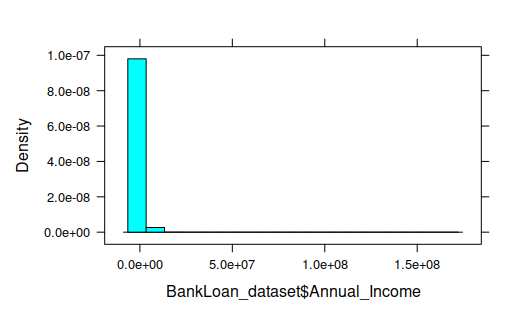

```r
# show outliers before removing them
histogram(BankLoan_dataset$Annual_Income)
```

```r
bankloan <- BankLoan_dataset %>%
  # convert string feature into categorical factors
  mutate_if(is.character, as.factor) %>%

  # remove the nulls
  drop_na() %>%

  ### Remove outliers
  # Annual_Income
  filter(between(Annual_Income,
                 quantile(Annual_Income, 0.25) - 1.5* IQR(Annual_Income),
                 quantile(Annual_Income, 0.75) + 1.5* IQR(Annual_Income))) %>%
  # Current_Loan_Amount
  filter(between(Current_Loan_Amount,
                 quantile(Current_Loan_Amount, 0.25) - 1.5* IQR(Current_Loan_Amount),
                 quantile(Current_Loan_Amount, 0.75) + 1.5* IQR(Current_Loan_Amount))) %>%
  # Credit_Score
  filter(between(Credit_Score,
                 quantile(Credit_Score, 0.25) - 1.5* IQR(Credit_Score),
                 quantile(Credit_Score, 0.75) + 1.5* IQR(Credit_Score))) %>%
  #Number_of_Credit_Problems (there is an outlier of 15)
  filter(between(Number_of_Credit_Problems,
                 quantile(Number_of_Credit_Problems, 0.25) - 1.5* IQR(Number_of_Credit_Problems),
                 4)) %>%
  # Monthly_Debt
  filter(between(Monthly_Debt,
               quantile(Monthly_Debt, 0.25) - 1.5* IQR(Monthly_Debt),
               quantile(Monthly_Debt, 0.75) + 1.5* IQR(Monthly_Debt))) %>%

  # Maximum_Open_Credit
  filter(between(Maximum_Open_Credit,
               quantile(Maximum_Open_Credit, 0.25) - 1.5* IQR(Maximum_Open_Credit),
               quantile(Maximum_Open_Credit, 0.75) + 1.5* IQR(Maximum_Open_Credit))) %>%

  #remove null after filling outliers with NA
  drop_na()

str(bankloan)
```

```
'data.frame':   25185 obs. of  17 variables:
 $ Loan_Status                 : Factor w/ 2 levels "Charged Off",..: 2 2 2 1 2 2 1 2 2 1 ...
 $ Current_Loan_Amount         : int  217646 548746 234124 317108 465410 449108 688468 129712 287980 374176 ...
 $ Term                        : Factor w/ 2 levels "Long Term","Short Term": 2 2 2 1 1 2 1 2 2 1 ...
 $ Credit_Score                : int  730 678 727 687 688 718 682 723 737 652 ...
 $ Annual_Income               : int  1184194 2559110 693234 1133274 1722654 1454507 1494616 1465698 1013954 1239199 ...
 $ Years_in_current_job        : num  1 2 10 8 3 8 1 10 1 10 ...
 $ Home_Ownership              : Factor w/ 4 levels "HaveMortgage",..: 2 4 4 4 4 2 4 3 2 2 ...
 $ Purpose                     : Factor w/ 16 levels "Business Loan",..: 4 4 4 4 3 4 4 4 4 10 ...
 $ Monthly_Debt                : num  10855 18660 14211 9633 15647 ...
 $ Years_of_Credit_History     : num  19.6 22.6 24.7 17.4 22.3 28.8 16.6 19.4 18.6 36.6 ...
 $ Months_since_last_delinquent: int  10 33 46 53 30 21 50 6 13 42 ...
 $ Number_of_Open_Accounts     : int  13 4 10 4 7 14 8 34 11 10 ...
 $ Number_of_Credit_Problems   : int  1 0 1 0 0 0 0 1 0 0 ...
 $ Current_Credit_Balance      : int  122170 437171 28291 60287 107559 193990 343995 45106 223117 126350 ...
 $ Maximum_Open_Credit         : int  272052 555038 107052 126940 488356 458414 843854 163218 489302 415602 ...
 $ Bankruptcies                : int  1 0 1 0 0 0 0 0 0 0 ...
 $ Tax_Liens                   : int  0 0 0 0 0 0 0 0 0 0 ...
```

```r
summary(bankloan)
```

```
      Loan_Status    Current_Loan_Amount         Term        Credit_Score
 Charged Off: 4628   Min.   : 21450      Long Term : 6672   Min.   :647.0
 Fully Paid :20557   1st Qu.:160336      Short Term:18513   1st Qu.:702.0
                     Median :259886                         Median :719.0
                     Mean   :289590                         Mean   :715.1
                     3rd Qu.:392436                         3rd Qu.:734.0
                     Max.   :789096                         Max.   :751.0

 Annual_Income     Years_in_current_job       Home_Ownership                Purpose
 Min.   : 111245   Min.   : 1.000       HaveMortgage :   59   Debt Consolidation:19640
 1st Qu.: 882911   1st Qu.: 3.000       Home Mortgage:12444   other             : 1633
 Median :1185961   Median : 6.000       Own Home     : 2175   Home Improvements : 1555
 Mean   :1277038   Mean   : 6.201       Rent         :10507   Other             :  812
 3rd Qu.:1580040   3rd Qu.:10.000                             Business Loan     :  357
 Max.   :2960447   Max.   :10.000                             Medical Bills     :  312
                                                              (Other)           :  876
  Monthly_Debt   Years_of_Credit_History Months_since_last_delinquent
 Min.   :    0   Min.   : 3.80           Min.   :  0.00
 1st Qu.:10559   1st Qu.:14.20           1st Qu.: 17.00
 Median :15993   Median :17.40           Median : 32.00
 Mean   :17067   Mean   :18.64           Mean   : 35.36
 3rd Qu.:22590   3rd Qu.:21.90           3rd Qu.: 52.00
 Max.   :43110   Max.   :70.50           Max.   :176.00

 Number_of_Open_Accounts Number_of_Credit_Problems Current_Credit_Balance
 Min.   : 2.00           Min.   :0.0000            Min.   :      0
 1st Qu.: 8.00           1st Qu.:0.0000            1st Qu.:  93841
 Median :10.00           Median :0.0000            Median : 170221
 Mean   :11.04           Mean   :0.1873            Mean   : 210122
 3rd Qu.:13.00           3rd Qu.:0.0000            3rd Qu.: 285703
 Max.   :48.00           Max.   :4.0000            Max.   :2028877

 Maximum_Open_Credit  Bankruptcies      Tax_Liens
 Min.   :      0     Min.   :0.0000   Min.   :0.00000
 1st Qu.: 231880     1st Qu.:0.0000   1st Qu.:0.00000
 Median : 384648     Median :0.0000   Median :0.00000
 Mean   : 448406     Mean   :0.1241   Mean   :0.02974
 3rd Qu.: 613426     3rd Qu.:0.0000   3rd Qu.:0.00000
 Max.   :1302114     Max.   :4.0000   Max.   :4.00000
```

```r
#check if there is null
is.null(bankloan)
```

```
[1] FALSE
```

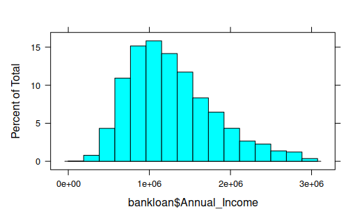

```r
# showing no outliers
histogram(bankloan$Annual_Income)
```

# STEP 3: STATISTICAL SUMMARY

## a) Graphical Summary

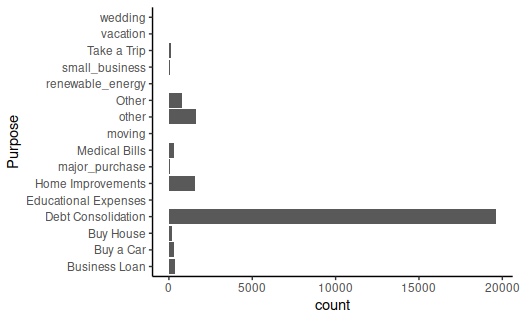

```r
# BAR graph for categorical variables

ggplot(bankloan, aes(x=Purpose)) +
  geom_bar() +
  coord_flip()
```

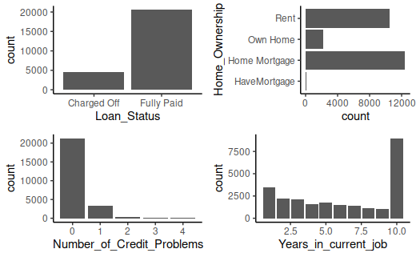

```r
gg_status <- ggplot(bankloan, aes(x=Loan_Status)) +
  geom_bar()

gg_home <- ggplot(bankloan, aes(x=Home_Ownership)) +
  geom_bar() +
  coord_flip()

gg_problem <- ggplot(bankloan, aes(x=Number_of_Credit_Problems)) +
  geom_bar()

gg_job <- ggplot(bankloan, aes(x=Years_in_current_job)) +
  geom_bar()

# arrange multiple plots in one figure
figure <- ggarrange(gg_status, gg_home, gg_problem, gg_job,
                    ncol = 2, nrow = 2,
                    legend="none")
figure
```

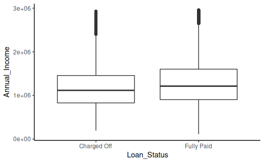

```r
# Boxplot for quantitative variables
ggplot(bankloan, aes(x=Loan_Status, y=Annual_Income)) +
  geom_boxplot()
```

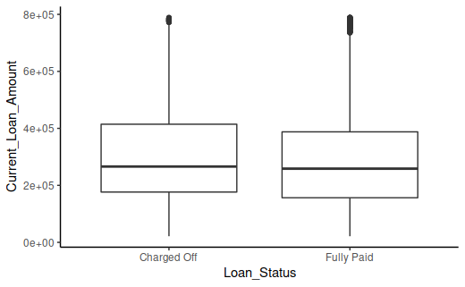

```r
ggplot(bankloan, aes(x=Loan_Status, y=Current_Loan_Amount)) +
  geom_boxplot()
```

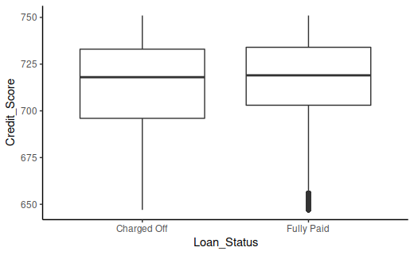

```r
ggplot(bankloan, aes(x=Loan_Status, y=Credit_Score)) +
  geom_boxplot()
```

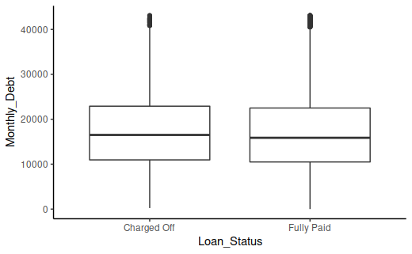

```r
ggplot(bankloan, aes(x=Loan_Status, y=Monthly_Debt)) +
  geom_boxplot()
```

From the Boxplots, comparing annual income, current loan amount, monthly debt and credit score, annual income seems to be the biggest difference between Fully Paid and Charged Off customers.

## b) Numerical Summary

```r
# proportion of Paid-fully and Charged-off
table(bankloan$Loan_Status)
```

```
Charged Off  Fully Paid
       4628       20557
```

```r
round(prop.table(table(bankloan$Loan_Status)) * 100, 1)
```

```
Charged Off  Fully Paid
       18.4        81.6
```

```r
# Average group by loan status
# Annual_Income is column5, credit score is column4
aggregate(bankloan[, 4:5], list(bankloan$Loan_Status), median)
```

| Group.1 | Credit_Score | Annual_Income |
| --- | --- | --- |
| Charged Off | 718 | 1116250 |
| Fully Paid | 719 | 1212561 |

```r
NA
```

# STEP 4: INITIAL EXPLORATION OF LINEAR REGRESSION MODEL

## a) Balancing Data by Downsampling

```r
set.seed(9650)
# Divide data into train and test sets
indexTrain <- createDataPartition(y=bankloan$Loan_Status, p=0.75, list=FALSE)
training <- bankloan[indexTrain, ]
testing <- bankloan[-indexTrain, ]

# Since there are 26000 of data, take a subset of data for visual clarity
training <- training[1:2000, ]
testing <- testing[1:500, ]

# Downsampling to balance data
sub_down_train <- downSample(x=training[, -ncol(training)], y=training$Loan_Status)
down_test <- downSample(x=testing[, -ncol(testing)], y=testing$Loan_Status)

table(sub_down_train$Loan_Status)
```

```
Charged Off  Fully Paid
        375         375
```

```r
table(down_test$Loan_Status)
```

```
Charged Off  Fully Paid
         93          93
```

Data are balanced with downsampling.

## b) Credit Score vs. Income

```r
# Credit Score as a function of Income
reg_model <- lm(Credit_Score ~ Annual_Income, data=sub_down_train)
# Linear regression model summary
reg_model
```

```
Call:
lm(formula = Credit_Score ~ Annual_Income, data = sub_down_train)

Coefficients:
  (Intercept)  Annual_Income
    7.180e+02     -3.378e-06
```

```r
# Create diagnostic plots
reg_model.diagnostic <- augment(reg_model)
knitr::kable(head(reg_model.diagnostic))
```

| Credit_Score | Annual_Income | .fitted | .resid | .hat | .sigma | .cooksd | .std.resid |
| --- | --- | --- | --- | --- | --- | --- | --- |
| 747 | 1839485 | 711.7482 | 35.251796 | 0.0032609 | 23.57221 | 0.0036643 | 1.4966817 |
| 710 | 1407900 | 713.2061 | -3.206063 | 0.0014954 | 23.60729 | 0.0000138 | -0.1359991 |
| 730 | 912475 | 714.8796 | 15.120432 | 0.0018650 | 23.60109 | 0.0003845 | 0.6415175 |
| 683 | 597493 | 715.9436 | -32.943551 | 0.0034319 | 23.57669 | 0.0033690 | -1.3988008 |
| 700 | 1630998 | 712.4525 | -12.452456 | 0.0021653 | 23.60318 | 0.0003029 | -0.5284023 |
| 723 | 590254 | 715.9680 | 7.031996 | 0.0034800 | 23.60618 | 0.0001557 | 0.2985895 |

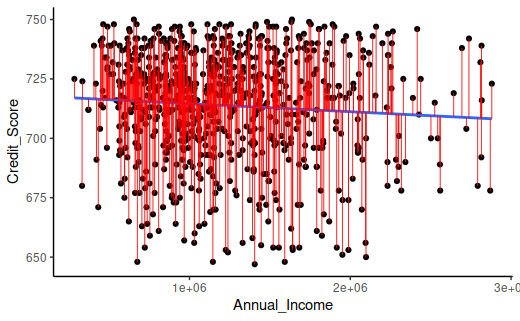

```r
# Scatter plot and best fitted line
ggplot(reg_model.diagnostic, aes(Annual_Income, Credit_Score)) +
  geom_point() +
  # linear model, don't show standard error
  stat_smooth(method=lm, se=FALSE) +
  #fitted shows the residual error
  geom_segment(aes(xend=Annual_Income, yend=.fitted), color='red', size=0.3)

# Diagnostic plots
par(mfrow = c(2,2))
```

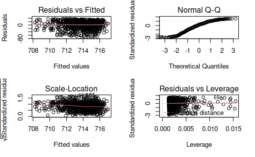

```r
plot(reg_model)
```

```r
# The diagnostic plots show residuals in four different ways:
#
# Residuals vs Fitted: This diagnostic plot is an indicator of the Linearity or Non Linearity of the relationship.If there is no perceivable pattern around the central horizontal curve then the relationship is linear.
#
# Normal Q-Q: This diagnostic plot ascertains whether the residuals are normally distributed.If the resiuals are algned to the central diagonal then the residuals follow a straight line.
#
# Scale-Location: This diagnostic is to evaluate the homogeneity of variance of the residuals .If the residuals are spread uniformly around the central line then the residuals are homoscedastic.
#
# Residuals vs Leverage. Used to identify influential cases, that is extreme values that might influence the regression results when included or excluded from the analysis.

# Cook's distance is used to evaluate the Influential points that will alter the Regression analysis or the coefficients values.
```

The scatter plot does not show much pattern in Credit Score vs. Annual Income. In the diagnostic plots: 1. It does not show very good linearity, there are more negative residual error than positive residual error. 2. Normality is not completely, because the two ends of the curve are not on the diagonal. 3. Constant Variance is true, because there is no apparent pattern on the residual error, homoscedastic is checked. 4. There are a few influential cases.

## c) IMPROVEMENT

### Current_Credit_Balance vs. Maximum_Open_Credit

```r
set.seed(9650)

# Credit Score as a function of Income
#reg_model <- lm(Credit_Score ~ Annual_Income, data=sub_down_train)
reg_model <- lm(Current_Credit_Balance ~ Maximum_Open_Credit, data=sub_down_train)
# Linear regression model summary
reg_model
```

```
Call:
lm(formula = Current_Credit_Balance ~ Maximum_Open_Credit, data = sub_down_train)

Coefficients:
        (Intercept)  Maximum_Open_Credit
           23112.80                 0.42
```

```r
# Create diagnostic plots
reg_model.diagnostic <- augment(reg_model)

knitr::kable(head(reg_model.diagnostic))
```

| Current_Credit_Balance | Maximum_Open_Credit | .fitted | .resid | .hat | .sigma | .cooksd | .std.resid |
| --- | --- | --- | --- | --- | --- | --- | --- |
| 270389 | 610280 | 279457.31 | -9068.307 | 0.0018719 | 97274.97 | 0.0000082 | -0.0933727 |
| 242098 | 292314 | 145897.57 | 96200.430 | 0.0017010 | 97211.73 | 0.0008357 | 0.9904522 |
| 29868 | 170368 | 94674.87 | -64806.874 | 0.0025884 | 97246.56 | 0.0005782 | -0.6675299 |
| 46930 | 301928 | 149935.87 | -103005.874 | 0.0016535 | 97202.38 | 0.0009313 | -1.0604939 |
| 295032 | 355476 | 172428.39 | 122603.606 | 0.0014490 | 97171.90 | 0.0011558 | 1.2621325 |
| 51053 | 74448 | 54384.25 | -3331.245 | 0.0036577 | 97275.46 | 0.0000022 | -0.0343312 |

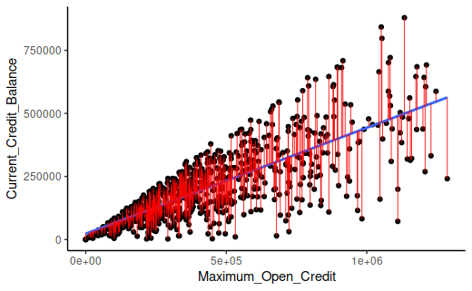

```r
# Scatter plot and best fitted line
#ggplot(reg_model.diagnostic, aes(Annual_Income, Credit_Score)) +
ggplot(reg_model.diagnostic, aes(Maximum_Open_Credit, Current_Credit_Balance)) +
  geom_point() +
  # linear model, don't show standard error
  stat_smooth(method=lm, se=FALSE) +
  #fitted shows the residual error
  geom_segment(aes(xend=Maximum_Open_Credit, yend=.fitted), color='red', size=0.3)

# Diagnostic plots
par(mfrow = c(2,2))
```

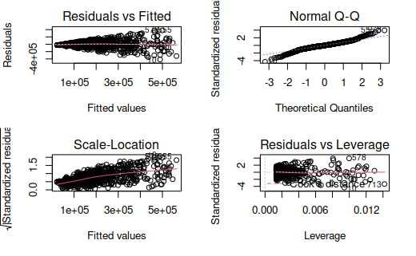

```r
plot(reg_model)
```

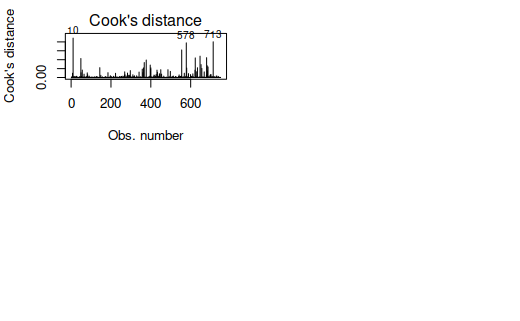

```r
plot(reg_model, 4)
```

```r
knitr::kable(head(sub_down_train), format='html')
```

| Loan_Status | Current_Loan_Amount | Term | Credit_Score | Annual_Income | Years_in_current_job | Home_Ownership | Purpose | Monthly_Debt | Years_of_Credit_History | Months_since_last_delinquent | Number_of_Open_Accounts | Number_of_Credit_Problems | Current_Credit_Balance | Maximum_Open_Credit | Bankruptcies | Class |
| --- | --- | --- | --- | --- | --- | --- | --- | --- | --- | --- | --- | --- | --- | --- | --- | --- |
| Charged Off | 538076 | Short Term | 747 | 1839485 | 10 | Rent | Debt Consolidation | 29891.56 | 14.4 | 28 | 7 | 0 | 270389 | 610280 | 0 | Charged Off |
| Charged Off | 217360 | Short Term | 710 | 1407900 | 1 | Home Mortgage | Debt Consolidation | 19710.60 | 8.0 | 2 | 11 | 0 | 242098 | 292314 | 0 | Charged Off |
| Charged Off | 280302 | Short Term | 730 | 912475 | 8 | Home Mortgage | Debt Consolidation | 14599.60 | 16.2 | 21 | 17 | 0 | 29868 | 170368 | 0 | Charged Off |
| Charged Off | 217558 | Short Term | 683 | 597493 | 10 | Own Home | Debt Consolidation | 3156.85 | 9.5 | 80 | 10 | 0 | 46930 | 301928 | 0 | Charged Off |
| Charged Off | 333278 | Long Term | 700 | 1630998 | 10 | Home Mortgage | Debt Consolidation | 17940.94 | 30.5 | 10 | 7 | 1 | 295032 | 355476 | 0 | Charged Off |
| Charged Off | 131428 | Short Term | 723 | 590254 | 1 | Rent | Debt Consolidation | 6714.03 | 12.9 | 29 | 7 | 0 | 51053 | 74448 | 0 | Charged Off |

```r
# The diagnostic plots show residuals in four different ways:
#
# Residuals vs Fitted: This diagnostic plot is an indicator of the Linearity or Non Linearity of the relationship.If there is no perceivable pattern around the central horizontal curve then the relationship is linear.
#
# Normal Q-Q: This diagnostic plot ascertains whether the residuals are normally distributed.If the resiuals are algned to the central diagonal then the residuals follow a straight line.
#
# Scale-Location: This diagnostic is to evaluate the homogeneity of variance of the residuals .If the residuals are spread uniformly around the central line then the residuals are homoscedastic.
#
# Residuals vs Leverage. Used to identify influential cases, that is extreme values that might influence the regression results when included or excluded from the analysis.

# Cook's distance is used to evaluate the Influential points that will alter the Regression analysis or the coefficients values.
```

# STEP 5: EXAMING FEATURES

## a) Feature Visualization

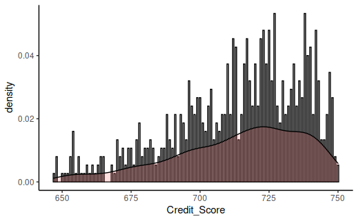

```r
transparentTheme(trans=.4)
#theme(plot.title = element_text(size = .1))

ggplot(sub_down_train, aes(x=Credit_Score)) +
  geom_histogram(aes(y=..density..), # histogram with density instead of count on y-axis
                 binwidth = 0.5,
                 colour='black', fill='white') +
  geom_density(alpha=0.2, fill='#FF6666')
```

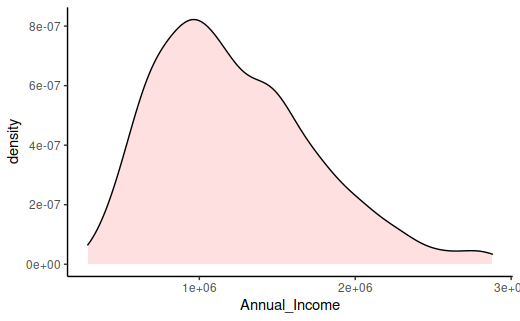

```r
ggplot(sub_down_train, aes(x=Annual_Income)) +
  geom_histogram(aes(y=..density..), # histogram with density instead of count on y-axis
                 binwidth = 0.5,
                 colour='black', fill='white') +
  geom_density(alpha=0.2, fill='#FF6666')
```

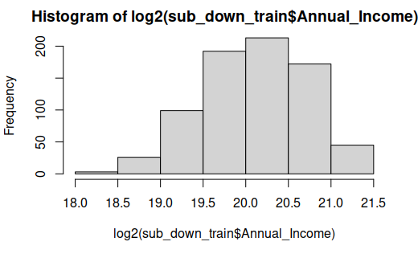

```r
# Try different methods to transform into normal distribution
hist(log2(sub_down_train$Annual_Income))
```

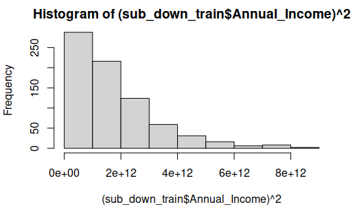

```r
hist((sub_down_train$Annual_Income)^2)
```

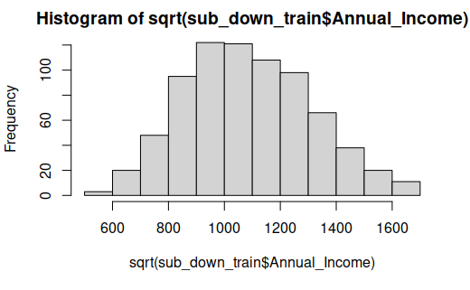

```r
hist(sqrt(sub_down_train$Annual_Income))
```

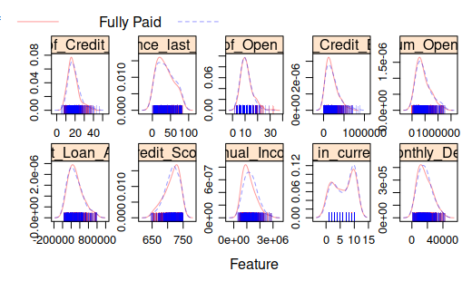

```r
# feature plots
# Taking only quantitative variables
featurePlot(x=sub_down_train[c(2,4,5,6,9,10,11,12,14,15)],
            y=sub_down_train$Loan_Status,
            plot='density',
            scales = list(x=list(relation='free'),
                          y=list(relation='free')),
            adjust=1.5,
            pch='|',
            layout = c(5,2),
             #number.cex = 0.05,
            auto.key=list(columns=5))
```

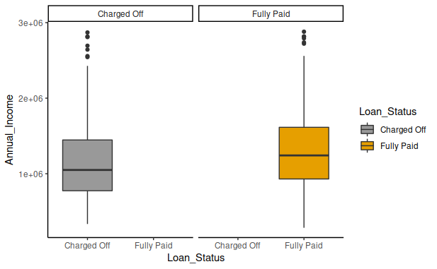

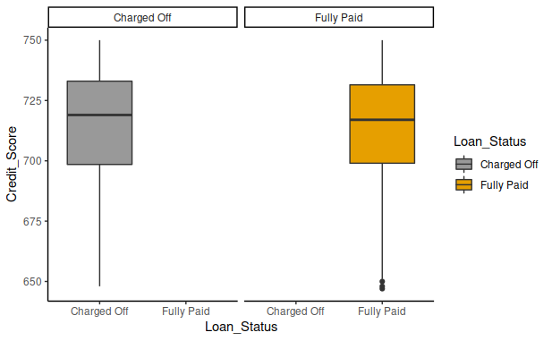

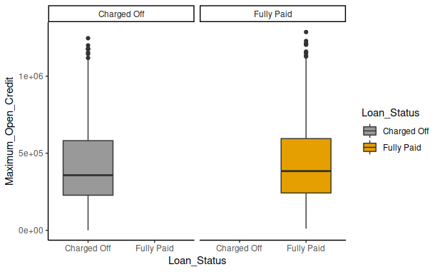

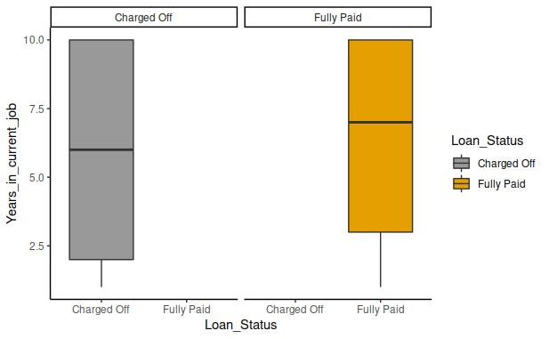

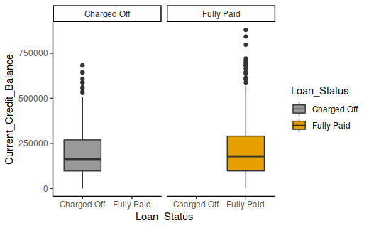

```r
# write a function to make boxplot of a list of variables
customPlot <- function(varName) {
  sub_down_train %>%
    group_by_('Loan_Status') %>%
    select_('Loan_Status', varName) %>%
    ggplot(aes_string('Loan_Status', varName, fill='Loan_Status')) +
    geom_boxplot() +
    scale_fill_manual(values=c('#999999', '#E69F00')) +
    facet_wrap(~Loan_Status)
}

varlist <- c('Annual_Income', 'Credit_Score', 'Maximum_Open_Credit', 'Years_in_current_job', 'Current_Credit_Balance')
lapply(varlist, customPlot)
```

Credit score is left-skew and Annual Income is right skewed. Using log2 and square do not transform Annual Income to normal distribution, but square root does transform it to normal.

Features plots show all the quantitative features and comparing base on Loan Status. The features plots give us better picture on what are the features that are very different between the two Loan Status (Fully Paid and Charged Off). For these very different features, boxplots are plotted for more detail visualization. Some of the boxplots were compared in Graphical Statisically Summary above but less systematic way. We see that Annual Income and Years in Current Jobs are most different between the two classes.

## b) Feature Correlation

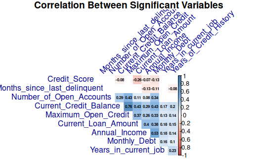

```r
# remove categorical variables, since correlation is for quantitative variables
correlation_r <- rcorr(as.matrix(sub_down_train[c(-1,-3,-7,-8,-13,-16,-17)]))

correlation_matrix <- correlation_r$r

# p-value
p_mat <- correlation_r$P
col <- colorRampPalette(c("#BB4444", "#EE9988", "#FFFFFF", "#77AADD", "#4477AA"))

# only plot variables with significant level above 0.05 (95% confidence)
corsig <- corrplot(correlation_matrix, method='color', col=col(200),
                   type='upper', order='hclust',
                   addCoef.col = 'black', # add coefficient of correlation
                   tl.col='darkblue', tl.srt = 45, # text label color and rotation
                   p.mat=p_mat, sig.level=0.05, insig='blank',
                   diag = FALSE,
                   title = 'Correlation Between Significant Variables',
                   mar=c(0,0,1,0),
                   number.cex = 0.5 # font for correlation coefficients
                   )
```

Feature correlation plot shows the features that are 95% confident that they are correlated. Current Credit Balance and Maximum Open Credit have strong correlation with r=0.76. This means the more money someone is allowed to borrow, the more they would borrow. Or the more someone borrows, the more they are allowed to borrow. Annual Income and Monthly Debt are moderately correlated with r=0.53. This means the more income one has, the more expenditure he/she will have and the more debt he/shw has.

# STEP 6: CLOSER LOOK OF LINEAR REGRESSION MODELS

## a) Current_Credit_Balance vs. Maximum_Open_Credit

```r
set.seed(9650)

# Remove influential cases
bankloan <-bankloan[c(-10, -578, -713), ]

# Set up train and test set
indexTrain <- createDataPartition(y=bankloan$Loan_Status, p=0.75, list=FALSE)
training <- bankloan[indexTrain, ]
testing <- bankloan[-indexTrain, ]

# Since there are 26000 of data, take a subset of data for visual clarity
training <- training[1:2000, ]
testing <- testing[1:500, ]

# Downsampling to balance data
sub_train <- downSample(x=training[, -ncol(training)], y=training$Loan_Status)
sub_test <- downSample(x=testing[, -ncol(testing)], y=testing$Loan_Status)

table(sub_train$Loan_Status)
```

```
Charged Off  Fully Paid
        375         375
```

```r
table(sub_test$Loan_Status)
```

```
Charged Off  Fully Paid
         92          92
```

```r
# Set up cross validation and control parameters
control <- trainControl(method='repeatedcv', number=10, repeats=1, verbose=FALSE, search='grid')
metric <- 'RMSE'
tunelength <- 10

# Train linear regression model
# fit_LR <- caret::train() if can't recognize the caret package
fit_LR <- train(Current_Credit_Balance ~ Maximum_Open_Credit, data=sub_train, method='lm', metric=metric, preProc=c('center', 'scale', 'BoxCox'), trControl=control, tunelength=tunelength, verbose=FALSE)
summary(fit_LR)
```

```
Call:
lm(formula = .outcome ~ ., data = dat, tunelength = ..1, verbose = FALSE)

Residuals:
    Min      1Q  Median      3Q     Max
-489492  -48938   -4516   49901  432640

Coefficients:
                    Estimate Std. Error t value Pr(>|t|)
(Intercept)           201592       3533   57.05   <2e-16 ***
Maximum_Open_Credit   110471       3536   31.24   <2e-16 ***
---
Signif. codes:  0 ‘***’ 0.001 ‘**’ 0.01 ‘*’ 0.05 ‘.’ 0.1 ‘ ’ 1

Residual standard error: 96760 on 748 degrees of freedom
Multiple R-squared:  0.5662,    Adjusted R-squared:  0.5656
F-statistic: 976.2 on 1 and 748 DF,  p-value: < 2.2e-16
```

```r
# Prediction
predictions <- predict(fit_LR, newdata=sub_test)

# Evaluation
rmse <- RMSE(predictions, sub_test$Current_Credit_Balance)
rmse
```

```
[1] 100576.1
```

```r
# Error rate
error_rate <- rmse/mean(sub_test$Current_Credit_Balance)
error_rate
```

```
[1] 0.472991
```

p-value is less than 2e-16. So the Current Open Credit and Maximum Open Credit relationship is significant. The intercept a=201592 and slope b=110471. 56% of the variation in Current Open Credit can be modeled by this linear relationship, and the rest 44% is due to other factors. This relationship means the more money someone is allowed to borrow, the more they would borrow. Error rate is 47%. This is moderately high considered all the outliers have been removed as well as the influential cases.

## b) Current Credit Balance vs. Annual Income

```r
# Set up cross validation and control parameters
control <- trainControl(method='repeatedcv', number=10, repeats=1, verbose=FALSE, search='grid')
metric <- 'RMSE'
tunelength <- 10

# Train linear regression model
# fit_LR <- caret::train() if can't recognize the caret package
fit_LR <- train(Current_Credit_Balance ~ Annual_Income, data=sub_train, method='lm', metric=metric, preProc=c('center', 'scale', 'BoxCox'), trControl=control, tunelength=tunelength, verbose=FALSE)
summary(fit_LR)
```

```
Call:
lm(formula = .outcome ~ ., data = dat, tunelength = ..1, verbose = FALSE)

Residuals:
    Min      1Q  Median      3Q     Max
-246894  -98682  -35492   73872  602654

Coefficients:
              Estimate Std. Error t value Pr(>|t|)
(Intercept)     201592       5147  39.168  < 2e-16 ***
Annual_Income    41397       5150   8.038 3.57e-15 ***
---
Signif. codes:  0 ‘***’ 0.001 ‘**’ 0.01 ‘*’ 0.05 ‘.’ 0.1 ‘ ’ 1

Residual standard error: 141000 on 748 degrees of freedom
Multiple R-squared:  0.0795,    Adjusted R-squared:  0.07827
F-statistic: 64.61 on 1 and 748 DF,  p-value: 3.566e-15
```

```r
# Prediction
predictions <- predict(fit_LR, newdata=sub_test)

# Evaluation
rmse <- RMSE(predictions, sub_test$Current_Credit_Balance)
rmse
```

```
[1] 147470
```

```r
# Error rate
error_rate <- rmse/mean(sub_test$Current_Credit_Balance)
error_rate
```

```
[1] 0.6935247
```

## c) Monthly Debt vs. Annual Income

```r
# Set up cross validation and control parameters
control <- trainControl(method='repeatedcv', number=10, repeats=1, verbose=FALSE, search='grid')
metric <- 'RMSE'
tunelength <- 10

# Train linear regression model
# fit_LR <- caret::train() if can't recognize the caret package
fit_LR <- train(Monthly_Debt ~ Annual_Income, data=sub_train, method='lm', metric=metric, preProc=c('center', 'scale', 'BoxCox'), trControl=control, tunelength=tunelength, verbose=FALSE)
summary(fit_LR)
```

```
Call:
lm(formula = .outcome ~ ., data = dat, tunelength = ..1, verbose = FALSE)

Residuals:
     Min       1Q   Median       3Q      Max
-21242.8  -5236.1   -614.1   5146.4  21540.0

Coefficients:
              Estimate Std. Error t value Pr(>|t|)
(Intercept)    16725.9      278.5   60.07   <2e-16 ***
Annual_Income   5021.6      278.6   18.02   <2e-16 ***
---
Signif. codes:  0 ‘***’ 0.001 ‘**’ 0.01 ‘*’ 0.05 ‘.’ 0.1 ‘ ’ 1

Residual standard error: 7626 on 748 degrees of freedom
Multiple R-squared:  0.3027,    Adjusted R-squared:  0.3018
F-statistic: 324.8 on 1 and 748 DF,  p-value: < 2.2e-16
```

```r
# Prediction
predictions <- predict(fit_LR, newdata=sub_test)

# Evaluation
rmse <- RMSE(predictions, sub_test$Monthly_Debt)
rmse
```

```
[1] 6667.515
```

```r
# Error rate
error_rate <- rmse/mean(sub_test$Monthly_Debt)
error_rate
```

```
[1] 0.402409
```

The relationship between Monthly Debt and Annual Income is also significant, since p-value=2e-16. The intercept a=16725.9. The slope b=5021.6. 30% of the variation in Monthly Debt can be modeled by this linear relationship, and the rest 70% is due to other factors. Error rate is 40%. This is moderately high considered all the outliers have been removed as well as the influential cases.

## d) Monthly Debt vs Annual_Income*Maximum_Open_Credit

```r
# Set up cross validation and control parameters
control <- trainControl(method='repeatedcv', number=10, repeats=1, verbose=FALSE, search='grid')
metric <- 'RMSE'
tunelength <- 10

# Train linear regression model
# fit_LR <- caret::train() if can't recognize the caret package
fit_LR <- train(Monthly_Debt ~ Annual_Income*Maximum_Open_Credit, data=sub_train, method='lm', metric=metric, preProc=c('center', 'scale', 'BoxCox'), trControl=control, tunelength=tunelength, verbose=FALSE)
summary(fit_LR)
```

```
Call:
lm(formula = .outcome ~ ., data = dat, tunelength = ..1, verbose = FALSE)

Residuals:
     Min       1Q   Median       3Q      Max
-19314.3  -4820.7   -409.7   4799.1  22815.3

Coefficients:
                                    Estimate Std. Error t value Pr(>|t|)
(Intercept)                         16725.93     272.04  61.484   <2e-16 ***
Annual_Income                        4633.24     457.02  10.138   <2e-16 ***
Maximum_Open_Credit                  1685.08     666.00   2.530   0.0116 *
`Annual_Income:Maximum_Open_Credit`    37.29     816.12   0.046   0.9636
---
Signif. codes:  0 ‘***’ 0.001 ‘**’ 0.01 ‘*’ 0.05 ‘.’ 0.1 ‘ ’ 1

Residual standard error: 7450 on 746 degrees of freedom
Multiple R-squared:  0.3363,    Adjusted R-squared:  0.3336
F-statistic:   126 on 3 and 746 DF,  p-value: < 2.2e-16
```

```r
# Prediction
predictions <- predict(fit_LR, newdata=sub_test)

# Evaluation
rmse <- RMSE(predictions, sub_test$Monthly_Debt)
rmse
```

```
[1] 6540.338
```

```r
# Error rate
error_rate <- rmse/mean(sub_test$Monthly_Debt)
error_rate
```

```
[1] 0.3947334
```

The relationship between Monthly Debt and the combined effects of Annual Income and Maximum Open Credit is also not significant, since p-value=0.96. This could be misleading because of multicollinearity between variables. The relationship is significant for each variable individually. The intercept a=16725.9. 33% of the variation in Monthly Debt can be modeled by this linear relationship, and the rest 67% is due to other factors. Error rate is 39%. This is moderately high considered all the outliers have been removed as well as the influential cases.

## e) Monthly Debt vs. Purpose

```r
#sub_train$Purpose <- as.character(sub_train$Purpose)
#sub_test$Purpose <- as.character(sub_test$Purpose)
sub_train$Purpose <- as.factor(sub_train$Purpose)
sub_test$Purpose <- as.factor(sub_test$Purpose)


# Set up cross validation and control parameters
control <- trainControl(method='repeatedcv', number=10, repeats=1, verbose=FALSE, search='grid')
metric <- 'RMSE'
tunelength <- 10

# Train linear regression model
# fit_LR <- caret::train() if can't recognize the caret package
fit_LR <- train(Monthly_Debt ~ Purpose, data=sub_train, method='lm', metric=metric, preProc=c('center', 'scale', 'BoxCox'), trControl=control, tunelength=tunelength, verbose=FALSE)
summary(fit_LR)
```

```
Call:
lm(formula = .outcome ~ ., data = dat, tunelength = ..1, verbose = FALSE)

Residuals:
   Min     1Q Median     3Q    Max
-18049  -6588  -1489   5439  25854

Coefficients: (3 not defined because of singularities)
                              Estimate Std. Error t value Pr(>|t|)
(Intercept)                   16725.93     329.39  50.779   <2e-16 ***
`PurposeBuy a Car`              -97.11     408.11  -0.238   0.8120
`PurposeBuy House`              -67.20     396.19  -0.170   0.8654
`PurposeDebt Consolidation`     734.37    1098.58   0.668   0.5040
`PurposeEducational Expenses`  -428.94     344.03  -1.247   0.2129
`PurposeHome Improvements`      231.93     690.53   0.336   0.7371
Purposemajor_purchase           429.28     357.84   1.200   0.2307
`PurposeMedical Bills`          373.74     452.37   0.826   0.4090
Purposemoving                       NA         NA      NA       NA
Purposeother                    -71.30     696.77  -0.102   0.9185
PurposeOther                   -385.01     578.46  -0.666   0.5059
Purposerenewable_energy             NA         NA      NA       NA
Purposesmall_business          -698.14     357.84  -1.951   0.0514 .
`PurposeTake a Trip`           -809.04     383.87  -2.108   0.0354 *
Purposevacation                -639.78     383.87  -1.667   0.0960 .
Purposewedding                      NA         NA      NA       NA
---
Signif. codes:  0 ‘***’ 0.001 ‘**’ 0.01 ‘*’ 0.05 ‘.’ 0.1 ‘ ’ 1

Residual standard error: 9021 on 737 degrees of freedom
Multiple R-squared:  0.03872,   Adjusted R-squared:  0.02307
F-statistic: 2.474 on 12 and 737 DF,  p-value: 0.003552
```

Purpose is a categorical variable. I am not sure how to interpredit when there is a p-value depending on the value of Purpose. But the combined p-value is 0.0035, so the relationship is significant and 2.3% of variation is due to this relationship.

## f) Monthly_Debt vs. Annual_Income+Current_Credit_Balance+Maximum_Open_Credit+Annual_Income*Maximum_Open_Credit

```r
# Set up cross validation and control parameters
control <- trainControl(method='repeatedcv', number=10, repeats=1, verbose=FALSE, search='grid')
metric <- 'RMSE'
tunelength <- 10

# Train linear regression model
# fit_LR <- caret::train() if can't recognize the caret package
fit_LR <- train(Monthly_Debt ~ Annual_Income+Current_Credit_Balance+Maximum_Open_Credit+Annual_Income*Maximum_Open_Credit, data=sub_train, method='lm', metric=metric, preProc=c('center', 'scale', 'BoxCox'), trControl=control, tunelength=tunelength, verbose=FALSE)
summary(fit_LR)
```

```
Call:
lm(formula = .outcome ~ ., data = dat, tunelength = ..1, verbose = FALSE)

Residuals:
     Min       1Q   Median       3Q      Max
-19967.7  -4770.0   -499.2   4684.7  22731.7

Coefficients:
                                    Estimate Std. Error t value Pr(>|t|)
(Intercept)                          16725.9      263.9  63.382  < 2e-16 ***
Annual_Income                         4673.9      443.4  10.542  < 2e-16 ***
Current_Credit_Balance                2857.0      413.3   6.912 1.03e-11 ***
Maximum_Open_Credit                    274.6      677.5   0.405    0.685
`Annual_Income:Maximum_Open_Credit`   -856.1      802.2  -1.067    0.286
---
Signif. codes:  0 ‘***’ 0.001 ‘**’ 0.01 ‘*’ 0.05 ‘.’ 0.1 ‘ ’ 1

Residual standard error: 7227 on 745 degrees of freedom
Multiple R-squared:  0.3763,    Adjusted R-squared:  0.373
F-statistic: 112.4 on 4 and 745 DF,  p-value: < 2.2e-16
```

The relationship of Monthly Debt is significant with Annual Income and with Current Credit Balance (just like predicted earlier). But the relationship is not significant with Maximum Open Credit or the combined effect of Annual Income and Maximum Open Credit. Again, this could be misleading because of multicollinearity between variables.

# STEP 7: NONLINEAR REGRESSION

## a) Polynomial

```r
set.seed(9650)

#
poly_reg <- lm(Monthly_Debt ~ poly(Annual_Income, 2), data=sub_train)
predictions <- poly_reg %>% predict(sub_test)

rmse <- RMSE(predictions, sub_test$Monthly_Debt)
rmse
```

```
[1] 6669.915
```

```r
R2 <- R2(predictions, sub_test$Monthly_Debt)
R2
```

```
[1] 0.3962137
```

```r
error_rate <- rmse/mean(sub_test$Monthly_Debt)
error_rate
```

```
[1] 0.4025539
```

## b) Splines

Smooth curve is fitted to the data with segments of polynomial terms called Knots.

```r
library(splines)
set.seed(9650)

knots <- quantile(sub_train$Monthly_Debt, p=c(0.25, 0.5, 0.75))

splinemodel <- lm(Monthly_Debt ~ bs(Annual_Income, knots=knots), data=sub_train)
summary(splinemodel)
```

```
Call:
lm(formula = Monthly_Debt ~ bs(Annual_Income, knots = knots),
    data = sub_train)

Residuals:
     Min       1Q   Median       3Q      Max
-20590.8  -5161.1   -433.2   5163.8  21187.4

Coefficients: (3 not defined because of singularities)
                                  Estimate Std. Error t value Pr(>|t|)
(Intercept)                          26782       2495  10.735  < 2e-16 ***
bs(Annual_Income, knots = knots)1       NA         NA      NA       NA
bs(Annual_Income, knots = knots)2       NA         NA      NA       NA
bs(Annual_Income, knots = knots)3   -25473       3566  -7.142 2.18e-12 ***
bs(Annual_Income, knots = knots)4    -4286       2836  -1.511    0.131
bs(Annual_Income, knots = knots)5    -2842       5622  -0.506    0.613
bs(Annual_Income, knots = knots)6       NA         NA      NA       NA
---
Signif. codes:  0 ‘***’ 0.001 ‘**’ 0.01 ‘*’ 0.05 ‘.’ 0.1 ‘ ’ 1

Residual standard error: 7621 on 746 degrees of freedom
Multiple R-squared:  0.3055,    Adjusted R-squared:  0.3027
F-statistic: 109.4 on 3 and 746 DF,  p-value: < 2.2e-16
```

```r
#Prediction
predictions <-  splinemodel %>% predict(sub_test)

# Performance
RMSE <- RMSE(predictions, sub_test$Monthly_Debt)
RMSE
```

```
[1] 6659.106
```

```r
R2 <- R2(predictions, sub_test$Monthly_Debt)
R2
```

```
[1] 0.3981749
```

```r
error_rate <- RMSE/mean(sub_test$Monthly_Debt)
error_rate
```

```
[1] 0.4019015
```

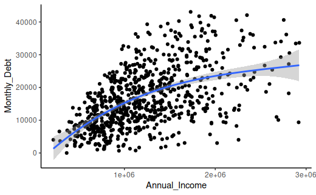

```r
# Visualization
ggplot(sub_train, aes(Annual_Income, Monthly_Debt)) +
  geom_point() +
  stat_smooth(method=lm, formula = y~splines::bs(x, df=3))
```

The results from Spline, adjusted R2 is 30%. Error rate is 40%. Both are the same as the linear relationship.

## c) Generalized Linear Model

Fits spline models with a selection of automate knots.

```r
library(mgcv)

gmmodel <- gam(Monthly_Debt ~ s(Annual_Income), data=sub_train)

# Predictions
gam_predictions <- gmmodel %>% predict(sub_test)

# Performance
RMSE <- RMSE(gam_predictions, sub_test$Monthly_Debt)
RMSE
```

```
[1] 6653.981
```

```r
R2 <- R2(gam_predictions, sub_test$Monthly_Debt)
R2
```

```
[1] 0.3995765
```

```r
error_rate <- RMSE/mean(sub_test$Monthly_Debt)
error_rate
```

```
[1] 0.4015922
```

gam model gives the same result as Spline.

## d) Multcollinearity

Variance inflation factor (VIF) quantifies the extend of correlation between one predictor variable and the other predictor variable. VIF below 1 is not correlated, 1-5 moderate, above 5 correlated.

```r
# Not include factor variables
train_nofactors <- sub_train[c(2,4,5,6,9,10,11,12,14,15)]

model_all <- lm(Monthly_Debt ~., data=train_nofactors)

car:: vif(model_all)
```

```
         Current_Loan_Amount                 Credit_Score                Annual_Income
                    1.478016                     1.132528                     1.289760
        Years_in_current_job      Years_of_Credit_History Months_since_last_delinquent
                    1.070972                     1.095007                     1.030608
     Number_of_Open_Accounts       Current_Credit_Balance          Maximum_Open_Credit
                    1.263647                     2.530783                     2.826373
```

# STEP 8: MODEL SELECTION, RIDGE AND LASSO REGRESSION

## a) Model Selection

```r
library(leaps)

checkmodels <- regsubsets(Annual_Income ~., data=sub_train, nvmax=13)
```

```
Reordering variables and trying again:
```

```r
summary(checkmodels)
```

```
Subset selection object
Call: regsubsets.formula(Annual_Income ~ ., data = sub_train, nvmax = 13)
32 Variables  (and intercept)
                             Forced in Forced out
Loan_StatusFully Paid            FALSE      FALSE
Current_Loan_Amount              FALSE      FALSE
TermShort Term                   FALSE      FALSE
Credit_Score                     FALSE      FALSE
Years_in_current_job             FALSE      FALSE
Home_OwnershipHome Mortgage      FALSE      FALSE
Home_OwnershipOwn Home           FALSE      FALSE
PurposeBuy a Car                 FALSE      FALSE
PurposeBuy House                 FALSE      FALSE
PurposeDebt Consolidation        FALSE      FALSE
PurposeEducational Expenses      FALSE      FALSE
```

[output cut: 158 more lines]

```r
# Find best model for R2, CP, and BIC, respectively
res_sum <- summary(checkmodels)
data.frame(Adj.R2=which.max(res_sum$adjr2), CP=which.min(res_sum$cp), BIC=which.min(res_sum$bic)) #, AIC=which.min(res_sum$AIC))
```

| Adj.R2 | CP | BIC |
| --- | --- | --- |
| 14 | 9 | 6 |

```r
# Best AIC model
library(MASS)

full_model <- lm(Annual_Income ~., data=sub_train)

step_model <- stepAIC(full_model, direction='both', trace=FALSE)
summary(step_model)
```

```
Call:
lm(formula = Annual_Income ~ Loan_Status + Current_Loan_Amount +
    Credit_Score + Home_Ownership + Monthly_Debt + Years_of_Credit_History +
    Months_since_last_delinquent + Number_of_Open_Accounts, data = sub_train)

Residuals:
    Min      1Q  Median      3Q     Max
-746781 -283939  -78076  205861 1753658

Coefficients:
                               Estimate Std. Error t value Pr(>|t|)
(Intercept)                  -9.768e+05  4.840e+05  -2.018 0.043913 *
Loan_StatusFully Paid         1.476e+05  2.986e+04   4.944 9.47e-07 ***
Current_Loan_Amount           8.136e-01  1.002e-01   8.116 2.01e-15 ***
Credit_Score                  2.228e+03  6.594e+02   3.378 0.000768 ***
Home_OwnershipOwn Home       -7.936e+04  5.656e+04  -1.403 0.160957
Home_OwnershipRent           -7.490e+04  3.157e+04  -2.372 0.017926 *
Monthly_Debt                  2.574e+01  1.867e+00  13.791  < 2e-16 ***
Years_of_Credit_History       4.872e+03  2.407e+03   2.024 0.043291 *
Months_since_last_delinquent -1.396e+03  6.579e+02  -2.121 0.034227 *
Number_of_Open_Accounts      -1.145e+04  3.499e+03  -3.273 0.001112 **
---
Signif. codes:  0 ‘***’ 0.001 ‘**’ 0.01 ‘*’ 0.05 ‘.’ 0.1 ‘ ’ 1

Residual standard error: 404400 on 740 degrees of freedom
Multiple R-squared:  0.3939,    Adjusted R-squared:  0.3866
F-statistic: 53.44 on 9 and 740 DF,  p-value: < 2.2e-16
```

Since Annual Income is the #1 most important feature in determining Loan Status, I decided to predict Annual Income base on all other variable. In terms of adjusted R2, Model #14 is the best. Model 14 accounts for Months_since_last_delinquent, Number_of_Open_Accounts, Monthly_Debt Years_of_Credit_History, Purpose, Loan_Status and Current_Loan_Amount. In terms of CP, Model #9 gives the best result. In terms of BIC, Model #6 gives the best result.

## b) Ridge Regression

Ridge Regression shrinks contribution from features of less prominent . Lasso Regression set zero for features of less prominent.

```r
library(glmnet)
set.seed(9650)

# Remove column 5 (Annual_Income)
x <- model.matrix(Annual_Income~., sub_train)[, -5]
y <- sub_train$Annual_Income

# alpha=0 for Ridge regression
cv <- cv.glmnet(x, y, alpha=0)
cv$lambda.min # Fit the final model with this paramter
```

```
[1] 39771.62
```

```r
model <- glmnet(x, y, alpha=0, lamba = cv $ lambda.min)
#coef(model)

# Predictions
x_test <- model.matrix(Annual_Income~., sub_test)[, -5]

predictions <- model %>% predict(x_test)  %>% as.vector

# Model Performance evaluation
RMSE <- RMSE(predictions, sub_test$Annual_Income)
RMSE
```

```
[1] 474698.8
```

# STEP 9: LOGISTIC REGRESSION

## a) Loan Status as a Function of Monthly Debt

```r
set.seed(9650)

logreg_debt <- glm(Loan_Status ~ Monthly_Debt, data=sub_train, family=binomial)
# Show coefficient
summary(logreg_debt)$coef
```

```
                  Estimate   Std. Error    z value  Pr(>|z|)
(Intercept)   8.499944e-02 1.526241e-01  0.5569203 0.5775819
Monthly_Debt -5.082193e-06 8.013337e-06 -0.6342167 0.5259394
```

The p-value for Loan Status and Monthly Debt relationship is 0.52. Meaning this relationship is not significant. So I will examing a different feature.

## b) IMPROVEMENT

### Loan Status as a Function of Income

```r
logreg_income <- glm(Loan_Status ~ Annual_Income, data=sub_train, family=binomial)
# Show coefficient
summary(logreg_income)$coef
```

[output not shown]

```r
# Predictions
logreg_probs <- logreg_income %>% predict(sub_test, type='response')

# Convert probability to integers
logreg_predictions <- ifelse(logreg_probs > 0.5, 'Fully Paid', 'Charged Off')
logreg_predictions <- as.factor(logreg_predictions)
typeof(logreg_predictions)
```

```
[1] "integer"
```

```r
typeof(sub_test$Loan_Status)
```

```
[1] "integer"
```

```r
# Performance confusion matrix to see accuracy and other parameter values
confusionMatrix(logreg_predictions, sub_test$Loan_Status)
```

[output not shown]

```r
# compute accuracy by comparing prediction with actual classification
mean(logreg_predictions == sub_test$Loan_Status)
```

[output not shown]

## c) IMPROVEMENT

### Using All of the Data

```r
# Set up train and test set
indexTrain <- createDataPartition(y=bankloan$Loan_Status, p=0.75, list=FALSE)
training <- bankloan[indexTrain, ]
testing <- bankloan[-indexTrain, ]

# Downsampling to balance data
sub_train <- downSample(x=training[, -ncol(training)], y=training$Loan_Status)
sub_test <- downSample(x=testing[, -ncol(testing)], y=testing$Loan_Status)

table(sub_train$Loan_Status)
```

```
Charged Off  Fully Paid
       3471        3471
```

```r
table(sub_test$Loan_Status)
```

```
Charged Off  Fully Paid
       1156        1156
```

```r
logreg_all <- glm(Loan_Status ~ Annual_Income, data=sub_train, family=binomial)
# Show coefficient
summary(logreg_all)$coef
```

```
                   Estimate   Std. Error   z value     Pr(>|z|)
(Intercept)   -4.989228e-01 6.297224e-02 -7.922901 2.320320e-15
Annual_Income  3.974048e-07 4.644018e-08  8.557348 1.154936e-17
```

```r
# Predictions
logreg_probs <- logreg_all %>% predict(sub_test, type='response')

# Convert probability to integers
logreg_pred_all <- ifelse(logreg_probs > 0.5, 'Fully Paid', 'Charged Off')
logreg_pred_all <- as.factor(logreg_pred_all)
typeof(logreg_pred_all)
```

```
[1] "integer"
```

```r
typeof(sub_test$Loan_Status)
```

```
[1] "integer"
```

```r
# Performance confusion matrix to see accuracy and other parameter values
confusionMatrix(logreg_pred_all, sub_test$Loan_Status)
```

```
Confusion Matrix and Statistics

             Reference
Prediction    Charged Off Fully Paid
  Charged Off         743        615
  Fully Paid          413        541

               Accuracy : 0.5554
                 95% CI : (0.5348, 0.5758)
    No Information Rate : 0.5
    P-Value [Acc > NIR] : 5.526e-08

                  Kappa : 0.1107

 Mcnemar's Test P-Value : 3.633e-10

            Sensitivity : 0.6427
            Specificity : 0.4680
         Pos Pred Value : 0.5471
         Neg Pred Value : 0.5671
             Prevalence : 0.5000
         Detection Rate : 0.3214
   Detection Prevalence : 0.5874
      Balanced Accuracy : 0.5554

       'Positive' Class : Charged Off
```

```r
# compute accuracy by comparing prediction with actual classification
mean(logreg_pred_all == sub_test$Loan_Status)
```

```
[1] 0.5553633
```

Using all of the data, the accuracy is still only 55%. The p-value shows this logistic regression relationship is significant. This is most like because Annual Income alone is not enough to predict Loan Status. I’ll try using all the features.

## d) IMPROVEMENT

### Using All Features

```r
logreg_all.features <- glm(Loan_Status ~., data=sub_train, family=binomial)
# Show coefficient
summary(logreg_all.features)$coef
```

```
                                  Estimate   Std. Error       z value
(Intercept)                  -2.656607e+01 1.967675e+05 -1.350125e-04
Current_Loan_Amount           1.440961e-17 3.367818e-02  4.278619e-16
TermShort Term               -1.177769e-11 1.141499e+04 -1.031774e-15
Credit_Score                  5.442891e-14 2.100988e+02  2.590634e-16
Annual_Income                 4.441767e-17 1.023603e-02  4.339345e-15
Years_in_current_job         -1.181779e-12 1.264725e+03 -9.344150e-16
Home_OwnershipHome Mortgage  -3.972246e-10 1.310473e+05 -3.031154e-15
Home_OwnershipOwn Home       -4.056080e-10 1.314500e+05 -3.085645e-15
Home_OwnershipRent           -4.002653e-10 1.307810e+05 -3.060578e-15
PurposeBuy a Car              4.379577e-10 5.419704e+04  8.080842e-15
PurposeBuy House             -2.488055e-11 6.065455e+04 -4.102009e-16
PurposeDebt Consolidation    -7.608269e-11 3.416664e+04 -2.226812e-15
PurposeEducational Expenses   2.216285e-09 1.494395e+05  1.483066e-14
PurposeHome Improvements     -7.069837e-11 3.818608e+04 -1.851417e-15
Purposemajor_purchase        -2.871844e-11 8.842087e+04 -3.247925e-16
PurposeMedical Bills         -4.698899e-11 5.174288e+04 -9.081248e-16
Purposemoving                -5.773524e-11 1.237235e+05 -4.666475e-16
Purposeother                 -7.619706e-11 3.771326e+04 -2.020431e-15
PurposeOther                 -5.044753e-11 4.174010e+04 -1.208611e-15
Purposerenewable_energy      -2.256003e-07 3.580272e+05 -6.301205e-13
Purposesmall_business        -3.271267e-11 8.340704e+04 -3.922052e-16
PurposeTake a Trip           -1.291325e-10 7.451346e+04 -1.733009e-15
Purposevacation              -7.653438e-11 1.178026e+05 -6.496833e-16
Purposewedding                2.324099e-10 9.800982e+04  2.371292e-15
Monthly_Debt                 -2.576922e-15 6.250883e-01 -4.122494e-15
Years_of_Credit_History       6.699434e-13 7.022457e+02  9.540014e-16
Months_since_last_delinquent  4.489371e-13 1.964779e+02  2.284925e-15
Number_of_Open_Accounts       4.460233e-12 1.075345e+03  4.147722e-15
Number_of_Credit_Problems    -7.937225e-12 1.405578e+04 -5.646946e-16
Current_Credit_Balance       -1.843036e-16 4.381155e-02 -4.206735e-15
Maximum_Open_Credit           1.572097e-16 2.529005e-02  6.216267e-15
Bankruptcies                  3.053027e-11 1.847019e+04  1.652948e-15
ClassFully Paid               5.313213e+01 8.736274e+03  6.081784e-03
                              Pr(>|z|)
(Intercept)                  0.9998923
Current_Loan_Amount          1.0000000
TermShort Term               1.0000000
Credit_Score                 1.0000000
Annual_Income                1.0000000
```

[output cut: 13 more lines]

```
PurposeOther                 1.0000000
Purposerenewable_energy      1.0000000
Purposesmall_business        1.0000000
PurposeTake a Trip           1.0000000
Purposevacation              1.0000000
Purposewedding               1.0000000
Monthly_Debt                 1.0000000
Years_of_Credit_History      1.0000000
Months_since_last_delinquent 1.0000000
Number_of_Open_Accounts      1.0000000
Number_of_Credit_Problems    1.0000000
Current_Credit_Balance       1.0000000
Maximum_Open_Credit          1.0000000
Bankruptcies                 1.0000000
ClassFully Paid              0.9951475
```

```r
# Predictions
logreg_probs.features <- logreg_all.features %>% predict(sub_test, type='response')

# Convert probability to integers
logreg_pred_all.features <- ifelse(logreg_probs.features > 0.5, 'Fully Paid', 'Charged Off')
logreg_pred_all.features <- as.factor(logreg_pred_all.features)
typeof(logreg_pred_all.features)
```

```
[1] "integer"
```

```r
typeof(sub_test$Loan_Status)
```

```
[1] "integer"
```

```r
# Performance confusion matrix to see accuracy and other parameter values
confusionMatrix(logreg_pred_all.features, sub_test$Loan_Status)
```

```
Confusion Matrix and Statistics

             Reference
Prediction    Charged Off Fully Paid
  Charged Off        1156          0
  Fully Paid            0       1156

               Accuracy : 1
                 95% CI : (0.9984, 1)
    No Information Rate : 0.5
    P-Value [Acc > NIR] : < 2.2e-16

                  Kappa : 1

 Mcnemar's Test P-Value : NA

            Sensitivity : 1.0
            Specificity : 1.0
         Pos Pred Value : 1.0
         Neg Pred Value : 1.0
             Prevalence : 0.5
         Detection Rate : 0.5
   Detection Prevalence : 0.5
      Balanced Accuracy : 1.0

       'Positive' Class : Charged Off
```

```r
# compute accuracy by comparing prediction with actual classification
mean(logreg_pred_all.features == sub_test$Loan_Status)
```

```
[1] 1
```

# CONCLUSION AND DISCUSSION

One weakness of this data is that there could be a large variation in the value, even after removing outliers and influential cases. There is a lot of variation when the numbers are high, such as at high Annual Income, high Monthly Debt, high Current Credit Balance, and high Maximum Open Credit. I supposed this could be due to different people manage money differently even among people with the same income.

In the future, I would like to implement PCA algorithms to treat multicollinearity properly. Also, I’d like to learn other algorithms like Neural Network and Deep Learning, and Naive Baye’s since my data have categorical variables.